# Aprendizaje no supervisado: Trade&Ahead

**Puntos: 60**

### Contexto

El mercado de valores ha demostrado constantemente ser un buen lugar para invertir y ahorrar para el futuro. Hay muchas razones convincentes para invertir en acciones. Puede ayudar a combatir la inflación, crear riqueza y también proporciona algunos beneficios fiscales. Los buenos rendimientos constantes de las inversiones durante un largo período de tiempo también pueden crecer mucho más de lo que parece posible. Además, gracias al poder del interés compuesto, cuanto antes se empieza a invertir, mayor es el corpus que se puede tener para la jubilación. En general, invertir en acciones puede ayudar a cumplir las aspiraciones financieras de la vida.

Es importante mantener una cartera diversificada al invertir en acciones para maximizar las ganancias bajo cualquier condición de mercado. Tener una cartera diversificada tiende a generar mayores rendimientos y enfrentar un menor riesgo al moderar las pérdidas potenciales cuando el mercado está a la baja. A menudo es fácil perderse en un mar de métricas financieras para analizar mientras se determina el valor de una acción, y hacer lo mismo para una multitud de acciones para identificar las opciones correctas para un individuo puede ser una tarea tediosa. Al hacer un análisis de conglomerados, se pueden identificar las acciones que exhiben características similares y las que exhiben una correlación mínima. Esto ayudará a los inversores a analizar mejor las acciones en diferentes segmentos del mercado y ayudará a protegerse contra los riesgos que podrían hacer que la cartera sea vulnerable a pérdidas.

### Objetivo

Trade&Ahead es una firma de consultoría financiera que brinda a sus clientes estrategias de inversión personalizadas. Lo contrataron como científico de datos y le proporcionaron datos que incluyen el precio de las acciones y algunos indicadores financieros para algunas empresas que cotizan en la Bolsa de Valores de Nueva York. Le han asignado las tareas de analizar los datos, agrupar las acciones en función de los atributos proporcionados y compartir información sobre las características de cada grupo.

### Diccionario de datos

- Ticker Symbol: una abreviatura utilizada para identificar de forma única las acciones que cotizan en bolsa de una acción en particular en un mercado de valores en particular
- Company: Nombre de la empresa
- GICS Sector: El sector económico específico asignado a una empresa por el Estándar de Clasificación de la Industria Global (GICS) que mejor define sus operaciones comerciales
- GICS Sub Industry: el grupo de subindustria específico asignado a una empresa por el Estándar de Clasificación de la Industria Global (GICS) que mejor define sus operaciones comerciales
- Current Price: Precio actual de la acción en dólares
- Price Change: cambio porcentual en el precio de las acciones en 13 semanas
- Volatility: Desviación estándar del precio de las acciones en las últimas 13 semanas
- ROE: una medida del rendimiento financiero que se calcula dividiendo los ingresos netos por el patrimonio de los accionistas (el patrimonio de los accionistas es igual a los activos de una empresa menos su deuda)
- Cash Ratio: La relación entre las reservas totales de efectivo y equivalentes de efectivo de una empresa y sus pasivos corrientes totales.
- Net Cash Flow: La diferencia entre las entradas y salidas de caja de una empresa (en dólares)
- Net Income: Ingresos menos gastos, intereses e impuestos (en dólares)
- Earnings Per Share: la utilidad neta de la empresa dividida por el número de acciones ordinarias que tiene en circulación (en dólares)
- Estimated Shares Outstanding: Acciones de la Compañía actualmente en poder de todos sus accionistas
- P/E Ratio: relación entre el precio actual de las acciones de la empresa y las ganancias por acción
- P/B Ratio: relación entre el precio de las acciones de la empresa por acción y su valor en libros por acción (el valor en libros de una empresa es la diferencia neta entre los activos totales y los pasivos totales de esa empresa)

## Importación de bibliotecas y datos necesarios

```python
# Libraries to help with reading and manipulating data
import numpy as np
import pandas as pd

# Libraries to help with data visualization
import matplotlib.pyplot as plt
import seaborn as sns

sns.set_theme(style='darkgrid')

# Removes the limit for the number of displayed columns
pd.set_option("display.max_columns", None)
# Sets the limit for the number of displayed rows
pd.set_option("display.max_rows", 200)

# to scale the data using z-score
from sklearn.preprocessing import StandardScaler

# to compute distances
from scipy.spatial.distance import cdist, pdist

# to perform k-means clustering and compute silhouette scores
from sklearn.cluster import KMeans
from sklearn.metrics import silhouette_score

# to visualize the elbow curve and silhouette scores
from yellowbrick.cluster import KElbowVisualizer, SilhouetteVisualizer

# to perform hierarchical clustering, compute cophenetic correlation, and create dendrograms
from sklearn.cluster import AgglomerativeClustering
from scipy.cluster.hierarchy import dendrogram, linkage, cophenet

# to suppress warnings
import warnings
warnings.filterwarnings("ignore")
```

```python
data = pd.read_csv('stock_data.csv')
```

```python
 pip install -U yellowbrick
```

## Resumen de datos

- Observaciones
- Controles de cordura

### Forma del DF

```python
data.head() #first rows
```

|  | Ticker Symbol | Security | GICS Sector | GICS Sub Industry | Current Price | Price Change | Volatility | ROE | Cash Ratio | Net Cash Flow | Net Income | Earnings Per Share | Estimated Shares Outstanding | P/E Ratio | P/B Ratio |
| --- | --- | --- | --- | --- | --- | --- | --- | --- | --- | --- | --- | --- | --- | --- | --- |
| 0 | AAL | American Airlines Group | Industrials | Airlines | 42.349998 | 9.999995 | 1.687151 | 135 | 51 | -604000000 | 7610000000 | 11.39 | 6.681299e+08 | 3.718174 | -8.784219 |
| 1 | ABBV | AbbVie | Health Care | Pharmaceuticals | 59.240002 | 8.339433 | 2.197887 | 130 | 77 | 51000000 | 5144000000 | 3.15 | 1.633016e+09 | 18.806350 | -8.750068 |
| 2 | ABT | Abbott Laboratories | Health Care | Health Care Equipment | 44.910000 | 11.301121 | 1.273646 | 21 | 67 | 938000000 | 4423000000 | 2.94 | 1.504422e+09 | 15.275510 | -0.394171 |
| 3 | ADBE | Adobe Systems Inc | Information Technology | Application Software | 93.940002 | 13.977195 | 1.357679 | 9 | 180 | -240840000 | 629551000 | 1.26 | 4.996437e+08 | 74.555557 | 4.199651 |
| 4 | ADI | Analog Devices, Inc. | Information Technology | Semiconductors | 55.320000 | -1.827858 | 1.701169 | 14 | 272 | 315120000 | 696878000 | 0.31 | 2.247994e+09 | 178.451613 | 1.059810 |

```python
data.tail() #last rows
```

|  | Ticker Symbol | Security | GICS Sector | GICS Sub Industry | Current Price | Price Change | Volatility | ROE | Cash Ratio | Net Cash Flow | Net Income | Earnings Per Share | Estimated Shares Outstanding | P/E Ratio | P/B Ratio |
| --- | --- | --- | --- | --- | --- | --- | --- | --- | --- | --- | --- | --- | --- | --- | --- |
| 335 | YHOO | Yahoo Inc. | Information Technology | Internet Software & Services | 33.259998 | 14.887727 | 1.845149 | 15 | 459 | -1032187000 | -4359082000 | -4.64 | 939457327.6 | 28.976191 | 6.261775 |
| 336 | YUM | Yum! Brands Inc | Consumer Discretionary | Restaurants | 52.516175 | -8.698917 | 1.478877 | 142 | 27 | 159000000 | 1293000000 | 2.97 | 435353535.4 | 17.682214 | -3.838260 |
| 337 | ZBH | Zimmer Biomet Holdings | Health Care | Health Care Equipment | 102.589996 | 9.347683 | 1.404206 | 1 | 100 | 376000000 | 147000000 | 0.78 | 188461538.5 | 131.525636 | -23.884449 |
| 338 | ZION | Zions Bancorp | Financials | Regional Banks | 27.299999 | -1.158588 | 1.468176 | 4 | 99 | -43623000 | 309471000 | 1.20 | 257892500.0 | 22.749999 | -0.063096 |
| 339 | ZTS | Zoetis | Health Care | Pharmaceuticals | 47.919998 | 16.678836 | 1.610285 | 32 | 65 | 272000000 | 339000000 | 0.68 | 498529411.8 | 70.470585 | 1.723068 |

```python
#shape of the data
print("There are", data.shape[0], 'rows and', data.shape[1], "columns.")
```

```
There are 340 rows and 15 columns.
```

```python
#sample of the data
data.sample(n=10, random_state=1)
```

|  | Ticker Symbol | Security | GICS Sector | GICS Sub Industry | Current Price | Price Change | Volatility | ROE | Cash Ratio | Net Cash Flow | Net Income | Earnings Per Share | Estimated Shares Outstanding | P/E Ratio | P/B Ratio |
| --- | --- | --- | --- | --- | --- | --- | --- | --- | --- | --- | --- | --- | --- | --- | --- |
| 102 | DVN | Devon Energy Corp. | Energy | Oil & Gas Exploration & Production | 32.000000 | -15.478079 | 2.923698 | 205 | 70 | 830000000 | -14454000000 | -35.55 | 4.065823e+08 | 93.089287 | 1.785616 |
| 125 | FB | Facebook | Information Technology | Internet Software & Services | 104.660004 | 16.224320 | 1.320606 | 8 | 958 | 592000000 | 3669000000 | 1.31 | 2.800763e+09 | 79.893133 | 5.884467 |
| 11 | AIV | Apartment Investment & Mgmt | Real Estate | REITs | 40.029999 | 7.578608 | 1.163334 | 15 | 47 | 21818000 | 248710000 | 1.52 | 1.636250e+08 | 26.335526 | -1.269332 |
| 248 | PG | Procter & Gamble | Consumer Staples | Personal Products | 79.410004 | 10.660538 | 0.806056 | 17 | 129 | 160383000 | 636056000 | 3.28 | 4.913916e+08 | 24.070121 | -2.256747 |
| 238 | OXY | Occidental Petroleum | Energy | Oil & Gas Exploration & Production | 67.610001 | 0.865287 | 1.589520 | 32 | 64 | -588000000 | -7829000000 | -10.23 | 7.652981e+08 | 93.089287 | 3.345102 |
| 336 | YUM | Yum! Brands Inc | Consumer Discretionary | Restaurants | 52.516175 | -8.698917 | 1.478877 | 142 | 27 | 159000000 | 1293000000 | 2.97 | 4.353535e+08 | 17.682214 | -3.838260 |
| 112 | EQT | EQT Corporation | Energy | Oil & Gas Exploration & Production | 52.130001 | -21.253771 | 2.364883 | 2 | 201 | 523803000 | 85171000 | 0.56 | 1.520911e+08 | 93.089287 | 9.567952 |
| 147 | HAL | Halliburton Co. | Energy | Oil & Gas Equipment & Services | 34.040001 | -5.101751 | 1.966062 | 4 | 189 | 7786000000 | -671000000 | -0.79 | 8.493671e+08 | 93.089287 | 17.345857 |
| 89 | DFS | Discover Financial Services | Financials | Consumer Finance | 53.619999 | 3.653584 | 1.159897 | 20 | 99 | 2288000000 | 2297000000 | 5.14 | 4.468872e+08 | 10.431906 | -0.375934 |
| 173 | IVZ | Invesco Ltd. | Financials | Asset Management & Custody Banks | 33.480000 | 7.067477 | 1.580839 | 12 | 67 | 412000000 | 968100000 | 2.26 | 4.283628e+08 | 14.814159 | 4.218620 |

### Tipos de datos

```python
# checking the column names and datatypes
data.info()
```

```
<class 'pandas.core.frame.DataFrame'>
RangeIndex: 340 entries, 0 to 339
Data columns (total 15 columns):
 #   Column                        Non-Null Count  Dtype
---  ------                        --------------  -----
 0   Ticker Symbol                 340 non-null    object
 1   Security                      340 non-null    object
 2   GICS Sector                   340 non-null    object
 3   GICS Sub Industry             340 non-null    object
 4   Current Price                 340 non-null    float64
 5   Price Change                  340 non-null    float64
 6   Volatility                    340 non-null    float64
 7   ROE                           340 non-null    int64
 8   Cash Ratio                    340 non-null    int64
 9   Net Cash Flow                 340 non-null    int64
 10  Net Income                    340 non-null    int64
 11  Earnings Per Share            340 non-null    float64
 12  Estimated Shares Outstanding  340 non-null    float64
 13  P/E Ratio                     340 non-null    float64
 14  P/B Ratio                     340 non-null    float64
dtypes: float64(7), int64(4), object(4)
memory usage: 40.0+ KB
```

```python
df = data.copy()
```

```python
df.isnull().sum() #comprobacion de valores faltantes
```

```
Ticker Symbol                   0
Security                        0
GICS Sector                     0
GICS Sub Industry               0
Current Price                   0
Price Change                    0
Volatility                      0
ROE                             0
Cash Ratio                      0
Net Cash Flow                   0
Net Income                      0
Earnings Per Share              0
Estimated Shares Outstanding    0
P/E Ratio                       0
P/B Ratio                       0
dtype: int64
```

```python
print(df.duplicated().sum()) #comprobacion de duplicados
```

```
0
```

### Resumen estadistico

```python
df.describe(include='all').T
```

|  | count | unique | top | freq | mean | std | min | 25% | 50% | 75% | max |
| --- | --- | --- | --- | --- | --- | --- | --- | --- | --- | --- | --- |
| Ticker Symbol | 340 | 340 | AAL | 1 | NaN | NaN | NaN | NaN | NaN | NaN | NaN |
| Security | 340 | 340 | American Airlines Group | 1 | NaN | NaN | NaN | NaN | NaN | NaN | NaN |
| GICS Sector | 340 | 11 | Industrials | 53 | NaN | NaN | NaN | NaN | NaN | NaN | NaN |
| GICS Sub Industry | 340 | 104 | Oil & Gas Exploration & Production | 16 | NaN | NaN | NaN | NaN | NaN | NaN | NaN |
| Current Price | 340.0 | NaN | NaN | NaN | 80.862345 | 98.055086 | 4.5 | 38.555 | 59.705 | 92.880001 | 1274.949951 |
| Price Change | 340.0 | NaN | NaN | NaN | 4.078194 | 12.006338 | -47.129693 | -0.939484 | 4.819505 | 10.695493 | 55.051683 |
| Volatility | 340.0 | NaN | NaN | NaN | 1.525976 | 0.591798 | 0.733163 | 1.134878 | 1.385593 | 1.695549 | 4.580042 |
| ROE | 340.0 | NaN | NaN | NaN | 39.597059 | 96.547538 | 1.0 | 9.75 | 15.0 | 27.0 | 917.0 |
| Cash Ratio | 340.0 | NaN | NaN | NaN | 70.023529 | 90.421331 | 0.0 | 18.0 | 47.0 | 99.0 | 958.0 |
| Net Cash Flow | 340.0 | NaN | NaN | NaN | 55537620.588235 | 1946365312.175789 | -11208000000.0 | -193906500.0 | 2098000.0 | 169810750.0 | 20764000000.0 |
| Net Income | 340.0 | NaN | NaN | NaN | 1494384602.941176 | 3940150279.327937 | -23528000000.0 | 352301250.0 | 707336000.0 | 1899000000.0 | 24442000000.0 |
| Earnings Per Share | 340.0 | NaN | NaN | NaN | 2.776662 | 6.587779 | -61.2 | 1.5575 | 2.895 | 4.62 | 50.09 |
| Estimated Shares Outstanding | 340.0 | NaN | NaN | NaN | 577028337.75403 | 845849595.417695 | 27672156.86 | 158848216.1 | 309675137.8 | 573117457.325 | 6159292035.0 |
| P/E Ratio | 340.0 | NaN | NaN | NaN | 32.612563 | 44.348731 | 2.935451 | 15.044653 | 20.819876 | 31.764755 | 528.039074 |
| P/B Ratio | 340.0 | NaN | NaN | NaN | -1.718249 | 13.966912 | -76.119077 | -4.352056 | -1.06717 | 3.917066 | 129.064585 |

## Análisis exploratorio de datos (EDA)

- EDA es una parte importante de cualquier proyecto que involucre datos.
- Es importante investigar y comprender mejor los datos antes de construir un modelo con ellos.
- A continuación se mencionan algunas preguntas que lo ayudarán a abordar el análisis de la manera correcta y generar conocimientos a partir de los datos.
- Se debe realizar un análisis exhaustivo de los datos, además de las preguntas que se mencionan a continuación.

## Analisis univariado

```python
# function to plot a boxplot and a histogram along the same scale.


def histogram_boxplot(df, feature, figsize=(12, 7), kde=False, bins=None):
    """
    Boxplot and histogram combined

    data: dataframe
    feature: dataframe column
    figsize: size of figure (default (12,7))
    kde: whether to the show density curve (default False)
    bins: number of bins for histogram (default None)
    """
    f2, (ax_box2, ax_hist2) = plt.subplots(
        nrows=2,  # Number of rows of the subplot grid= 2
        sharex=True,  # x-axis will be shared among all subplots
        gridspec_kw={"height_ratios": (0.25, 0.75)},
        figsize=figsize,
    )  # creating the 2 subplots
    sns.boxplot(
        data=df, x=feature, ax=ax_box2, showmeans=True, color="violet"
    )  # boxplot will be created and a star will indicate the mean value of the column
    sns.histplot(
        data=df, x=feature, kde=kde, ax=ax_hist2, bins=bins, palette="winter"
    ) if bins else sns.histplot(
        data=df, x=feature, kde=kde, ax=ax_hist2
    )  # For histogram
    ax_hist2.axvline(
        df[feature].mean(), color="green", linestyle="--"
    )  # Add mean to the histogram
    ax_hist2.axvline(
        df[feature].median(), color="black", linestyle="-"
    )  # Add median to the histogram
```

```python
# function to create labeled barplots


def labeled_barplot(df, feature, perc=False, n=None):
    """
    Barplot with percentage at the top

    data: dataframe
    feature: dataframe column
    perc: whether to display percentages instead of count (default is False)
    n: displays the top n category levels (default is None, i.e., display all levels)
    """

    total = len(df[feature])  # length of the column
    count = df[feature].nunique()
    if n is None:
        plt.figure(figsize=(count + 1, 5))
    else:
        plt.figure(figsize=(n + 1, 5))

    plt.xticks(rotation=90, fontsize=15)
    ax = sns.countplot(
        data=df,
        x=feature,
        palette="Paired",
        order=df[feature].value_counts().index[:n].sort_values(),
    )

    for p in ax.patches:
        if perc == True:
            label = "{:.1f}%".format(
                100 * p.get_height() / total
            )  # percentage of each class of the category
        else:
            label = p.get_height()  # count of each level of the category

        x = p.get_x() + p.get_width() / 2  # width of the plot
        y = p.get_height()  # height of the plot

        ax.annotate(
            label,
            (x, y),
            ha="center",
            va="center",
            size=12,
            xytext=(0, 5),
            textcoords="offset points",
        )  # annotate the percentage

    plt.show()  # show the plot
```

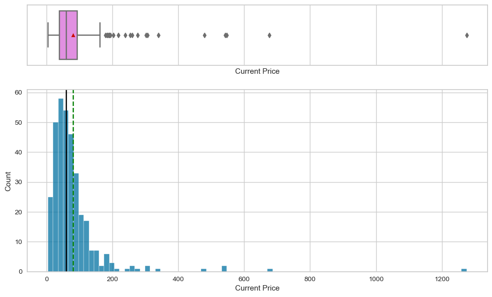

```python
histogram_boxplot(df, 'Current Price')
```

### Observaciones

Concentración de Precios Bajos: La mayoría de las acciones tienen precios bajos, con una concentración significativa de acciones en el extremo inferior del espectro de precios.

Asimetría a la Derecha: La distribución de los precios de las acciones está sesgada hacia la derecha, lo que indica que hay relativamente pocas acciones con precios muy altos.

Valores Atípicos: Existen valores atípicos claros que indican la presencia de acciones cuyos precios son mucho más altos que la mayoría.

Rango Intermedio Concentrado: La mediana y el rango intercuartílico del boxplot son bajos en comparación con el rango completo de precios, mostrando que los precios de las acciones están más agrupados hacia el extremo inferior.

Median vs. Mean: La mediana se encuentra cerca del cuartil inferior, y la media está situada más alta, lo que refleja la asimetría de la distribución.

Estas observaciones sugieren una distribución donde un número reducido de acciones con precios altos se desvía de un grupo más grande de acciones con precios más moderados, un patrón que puede tener implicaciones significativas para estrategias de inversión enfocadas en la diversificación y el análisis de riesgos.

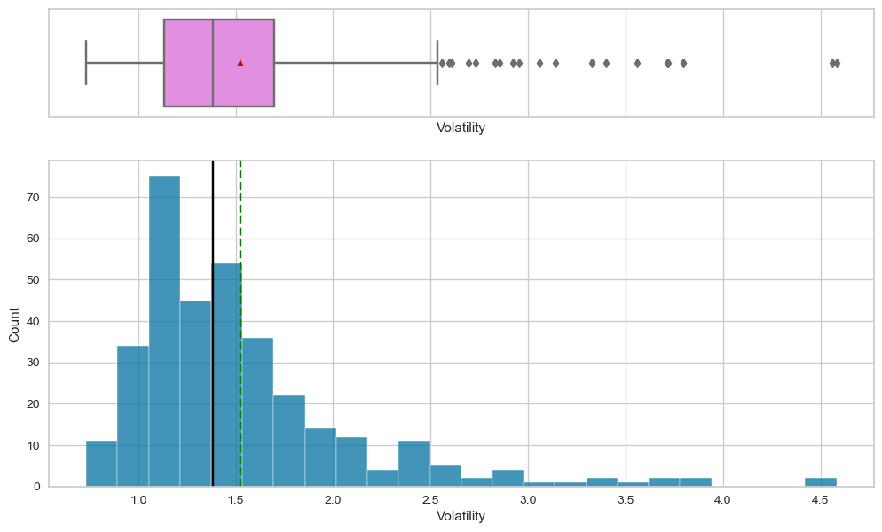

```python
histogram_boxplot(df, 'Volatility')
```

### Observaciones

Predominio de Baja Volatilidad: La mayoría de las acciones exhiben volatilidad baja a moderada.

Distribución Sesgada: La volatilidad de las acciones muestra un sesgo hacia la derecha, indicando menos acciones con alta volatilidad.

Concentración de Datos: La mediana y el rango intercuartílico son bajos, lo que sugiere que los datos están concentrados en valores de volatilidad más bajos.

Valores Atípicos: Hay acciones con volatilidad significativamente más alta que podrían representar un riesgo mayor o una oportunidad dependiendo de la estrategia de inversión.

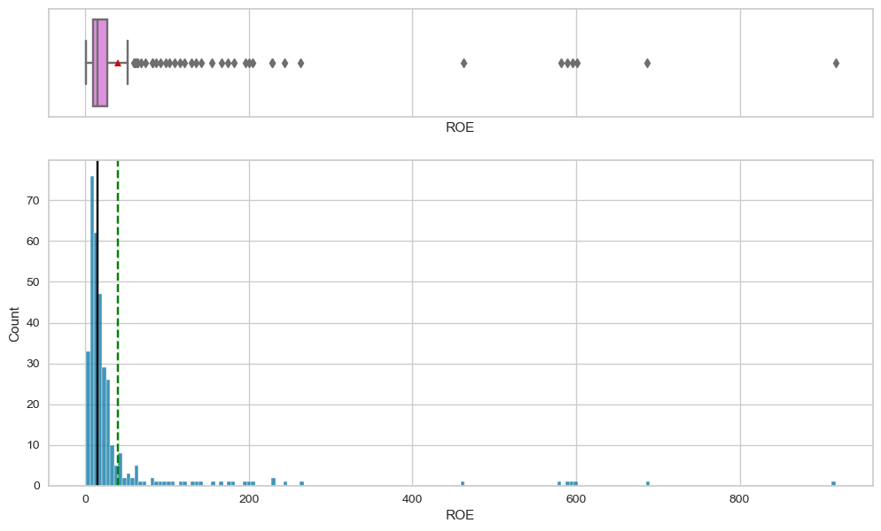

```python
histogram_boxplot(df, 'ROE')
```

### Observaciones

Concentración de ROE Bajo: La mayoría de las empresas tienen un ROE bajo, con un pico en la distribución cerca del valor cero.

Sesgo Positivo Extremo: La distribución es altamente asimétrica hacia la derecha, indicando que unas pocas empresas tienen valores de ROE excepcionalmente altos.

Rango Intermedio Estrecho: La mediana y el rango intercuartílico son muy bajos, lo que sugiere que el núcleo central de los datos está muy concentrado.

Valores Atípicos Pronunciados: Hay una cantidad significativa de valores atípicos que indican empresas con un ROE mucho más alto que el promedio.

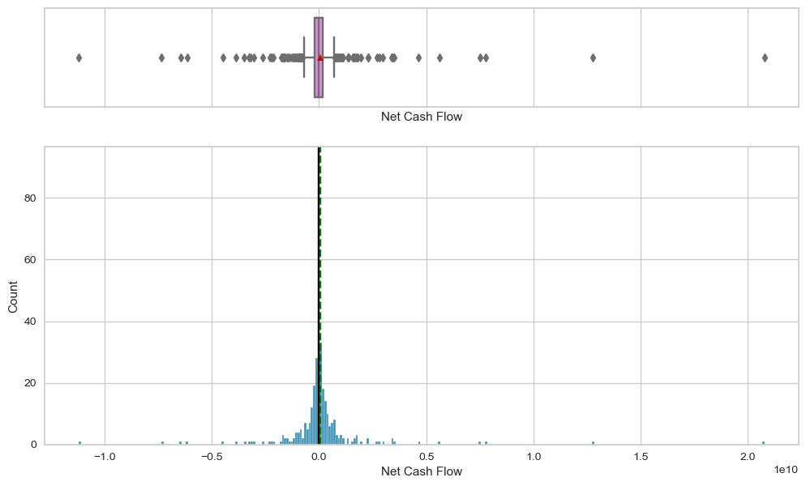

```python
histogram_boxplot(df, 'Net Cash Flow')
```

### Observaciones

Distribución Centralizada: La mayoría de las empresas tienen un flujo de caja neto cercano a cero, como se indica por la concentración de datos en torno a este valor en el histograma.

Simetría y Valores Atípicos: Hay una simetría aparente en torno al centro con valores atípicos en ambos extremos, indicando que algunas empresas experimentan flujos de caja netos significativamente positivos o negativos.

Valores Extremos: Aunque la mayoría de las empresas tienen flujos de caja netos moderados, hay casos extremos con flujos de caja netos muy altos o muy bajos.

Boxplot: El boxplot muestra que la mediana está cerca de cero y que los 'bigotes' se extienden a valores relativamente pequeños, lo que sugiere que la variabilidad típica en el flujo de caja neto es baja. Los valores atípicos indican situaciones financieras excepcionales.

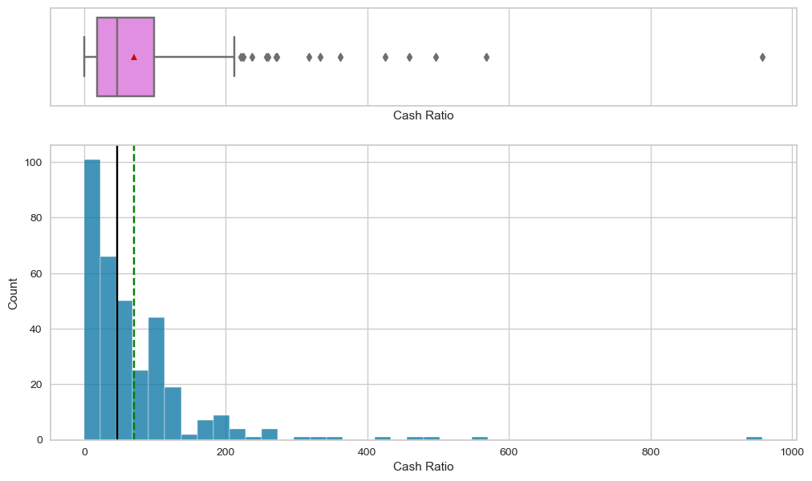

```python
histogram_boxplot(df, 'Cash Ratio')
```

### Observaciones

Concentración en Valores Bajos: La mayoría de las empresas tienen un Cash Ratio bajo, con un pico en la distribución cerca del cero.

Asimetría Positiva: La distribución es asimétrica hacia la derecha, lo que indica que hay menos empresas con un Cash Ratio alto.

Median y Rango Intermedio: La mediana está cerca del borde inferior de la caja en el boxplot, sugiriendo que más de la mitad de las empresas tienen un Cash Ratio bajo.

Valores Atípicos: Existen valores atípicos que representan empresas con un Cash Ratio mucho más alto que la mayoría.

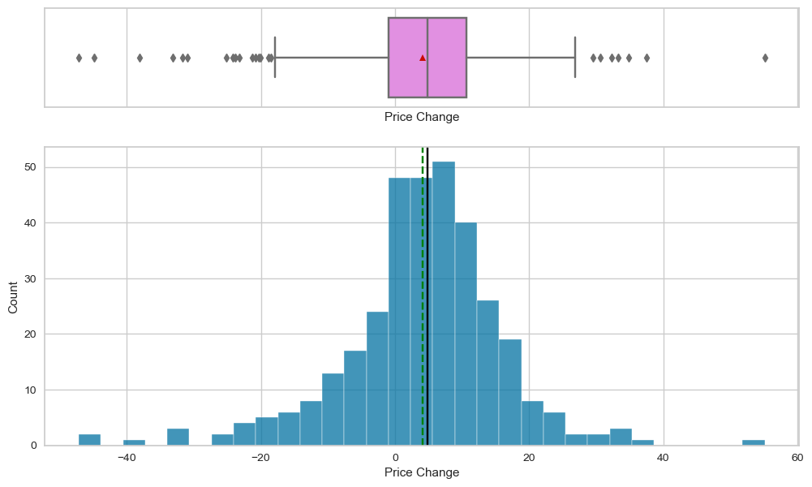

```python
histogram_boxplot(df, 'Price Change')
```

### Observaciones

Distribución Simétrica: La distribución de los cambios en el precio de las acciones parece ser bastante simétrica alrededor del valor cero.

Presencia de Valores Atípicos: Aunque la mayoría de los cambios de precio están cerca de cero, hay valores atípicos en ambos extremos, lo que indica que algunas acciones han experimentado cambios significativos en el precio.

Caja y 'Bigotes' del Boxplot: La caja y los 'bigotes' muestran que hay una variación razonable en el cambio de precio entre la mayoría de las acciones, pero sin una inclinación significativa hacia aumentos o disminuciones de precio.

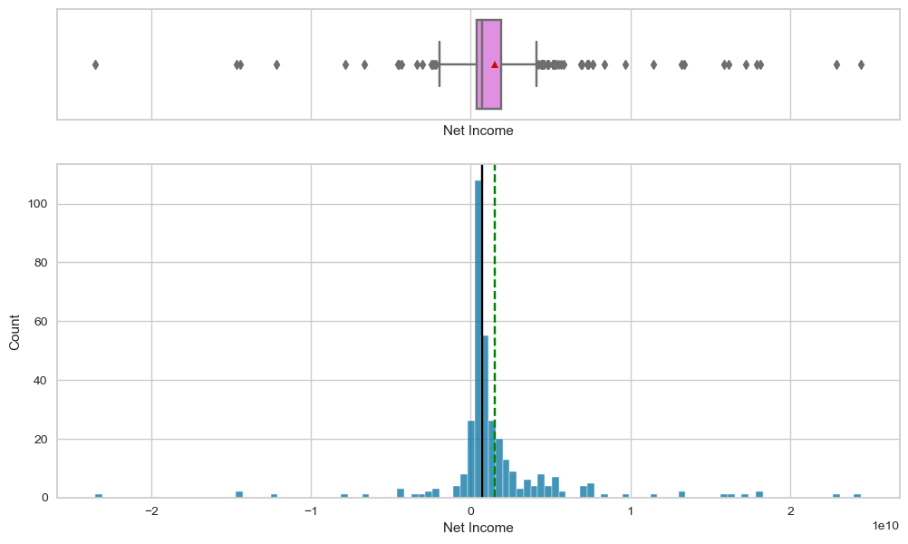

```python
histogram_boxplot(df, 'Net Income')
```

### Observaciones

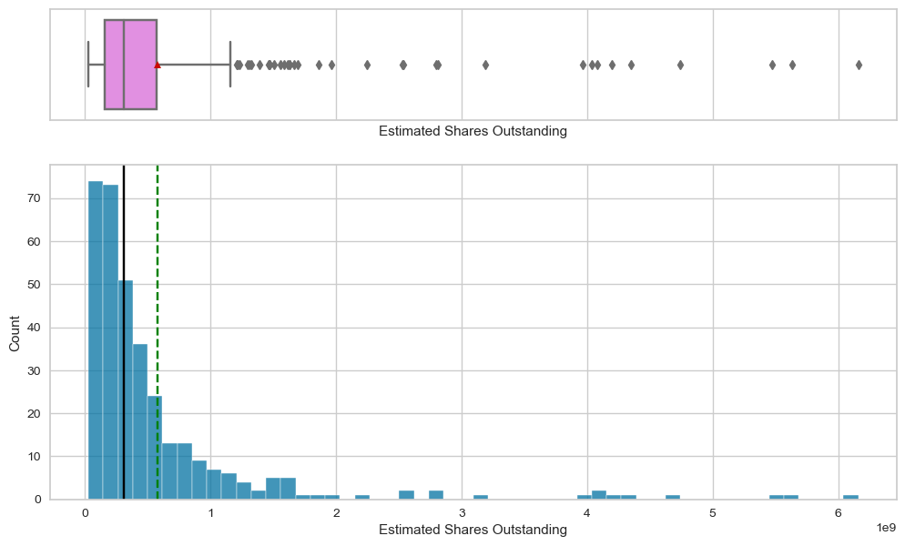

```python
histogram_boxplot(df, 'Estimated Shares Outstanding')
```

### Observaciones

Concentración de Valores Bajos: La mayoría de las empresas tienen un número relativamente bajo de acciones en circulación, con la mayor cantidad de datos concentrados en el extremo inferior del espectro.

Sesgo Positivo: La distribución es asimétrica hacia la derecha, lo que sugiere que hay algunas empresas con un número muy alto de acciones en circulación, aunque son mucho menos comunes.

Median y Rango Intermedio: La mediana, indicada por la línea roja en el boxplot, se encuentra cerca del extremo inferior del rango intercuartílico, reforzando la idea de que la mayoría de las empresas tienen menos acciones en circulación.

Presencia de Valores Atípicos: Hay valores atípicos presentes que representan empresas con un número mucho más grande de acciones en circulación en comparación con la mayoría de las empresas.

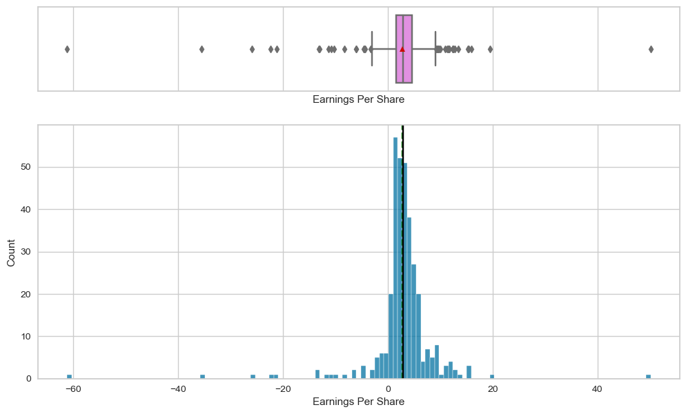

```python
histogram_boxplot(df, 'Earnings Per Share')
```

### Observaciones

Concentración de Ganancias Bajas: La mayoría de las empresas tienen ganancias por acción bajas o cercanas a cero, como indica el pico del histograma.

Valores Atípicos en Ambos Extremos: Hay valores atípicos en ambos lados del espectro, indicando que algunas empresas tienen ganancias por acción negativas significativas y otras tienen ganancias por acción positivas muy altas.

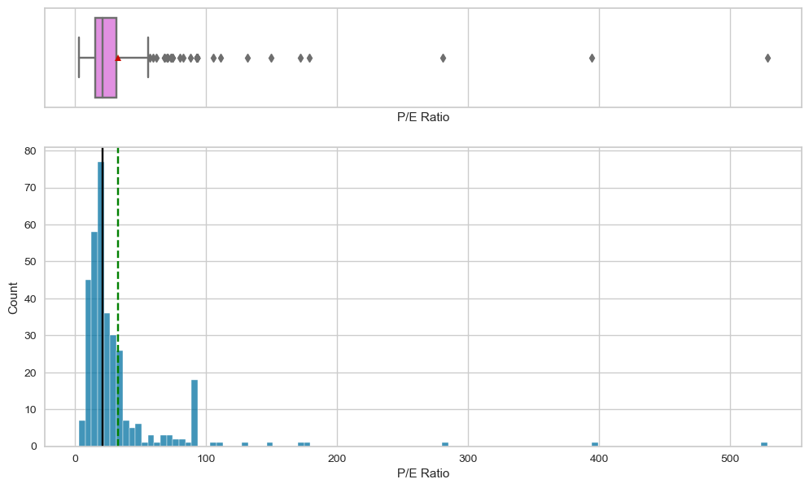

```python
histogram_boxplot(df, 'P/E Ratio')
```

### Observaciones

Concentración de Valores Bajos: La mayoría de las empresas tienen un P/E Ratio bajo, lo que se refleja en el pico del histograma cerca del valor cero.

Distribución Sesgada a la Derecha: La distribución muestra una clara asimetría hacia la derecha, lo que significa que hay algunas empresas con ratios P/E muy altos, pero son menos comunes.

Median y Rango Intermedio: La mediana (indicada por la línea roja en el boxplot) se encuentra hacia el extremo inferior del rango intercuartílico, lo que sugiere que más de la mitad de las empresas tienen ratios P/E bajos.

Valores Atípicos: Hay valores atípicos que indican que algunas empresas tienen ratios P/E extremadamente altos, mucho más allá de la tendencia general.

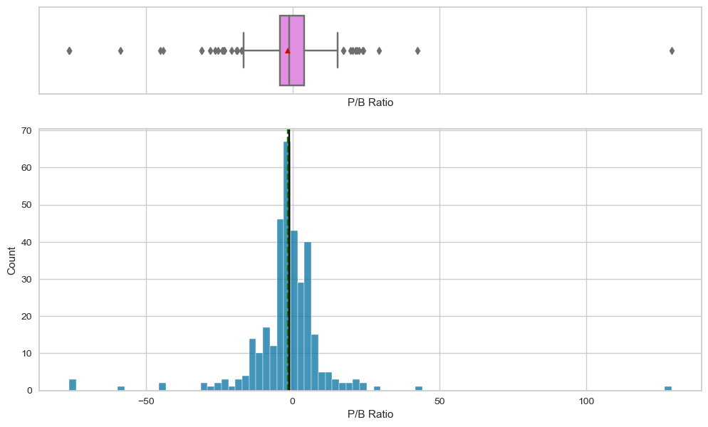

```python
histogram_boxplot(df, 'P/B Ratio')
```

### Observaciones

Concentración en Valores Bajos: La mayoría de las empresas tienen un P/B Ratio bajo, como se evidencia por la concentración de barras del histograma cerca del cero.

Valores Negativos: Hay valores en el rango negativo, lo que podría sugerir datos incorrectos o situaciones especiales donde la contabilidad de la empresa refleja un valor en libros negativo.

Valores Atípicos: Se observan valores atípicos que indican que algunas empresas tienen un P/B Ratio mucho más alto que el promedio.

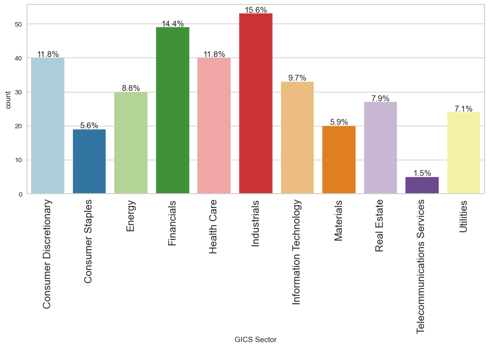

```python
labeled_barplot(df, 'GICS Sector', perc=True)
```

### Observaciones

Distribución Variada: Existe una variedad en la distribución de las empresas a través de los distintos sectores, lo que sugiere una diversidad en la muestra de empresas analizadas.

[figure not shown]

```python
labeled_barplot(df, 'GICS Sub Industry', perc=True)
```

### Observaciones

Podemos ver gráfico con muchas barras de diferentes alturas que puede indicar una diversa gama de subindustrias dentro del mercado de valores, lo que sugiere una amplia variedad de opciones para la inversión y la diversificación de la cartera.

### Análisis bivariado

**Preguntas**:

1. ¿Cómo es la distribución de los precios de las acciones?
2. ¿Las acciones de qué sector económico han visto el máximo aumento de precio en promedio?
3. ¿Cómo se correlacionan las diferentes variables entre sí?
4. El índice de efectivo proporciona una medida de la capacidad de una empresa para cubrir sus obligaciones a corto plazo utilizando solo efectivo y equivalentes de efectivo. ¿Cómo varía la razón de efectivo promedio entre los sectores económicos?
5. Las relaciones P/E pueden ayudar a determinar el valor relativo de las acciones de una empresa, ya que representan la cantidad de dinero que un inversionista está dispuesto a invertir en una sola acción de una empresa por cada dólar de sus ganancias. ¿Cómo varía la relación P/E, en promedio, entre sectores económicos?

### ¿Cómo se correlacionan las diferentes variables entre sí?

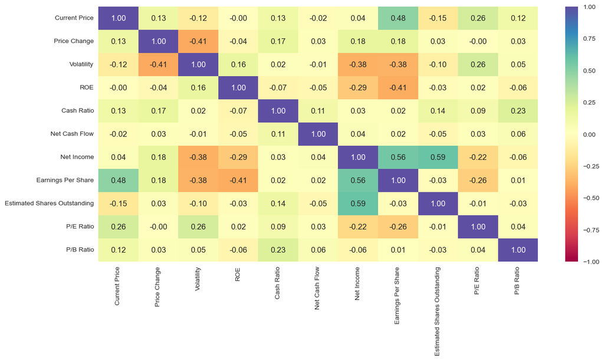

```python
plt.figure(figsize=(15, 7))
sns.heatmap(
    df.corr(), annot=True, vmin=-1, vmax=1, fmt=".2f", cmap="Spectral"
)
plt.show()
```

"Current Price" y "Earnings Per Share" tienen una correlación positiva moderada de 0.48, lo que sugiere que las empresas con precios de acciones más altos tienden a tener mayores ganancias por acción.

"Net Income" y "Earnings Per Share" tienen una correlación fuerte de 0.56, lo cual es esperado ya que las ganancias por acción se calculan a partir del ingreso neto.

"Price Change" tiene una correlación negativa moderada con "Volatility" de -0.41, lo que podría sugerir que las acciones con cambios de precio más grandes tienden a tener menor volatilidad, aunque esta interpretación puede no ser intuitiva y podría requerir una investigación más profunda.

### ¿Las acciones de qué sector económico han visto el máximo aumento de precio en promedio?

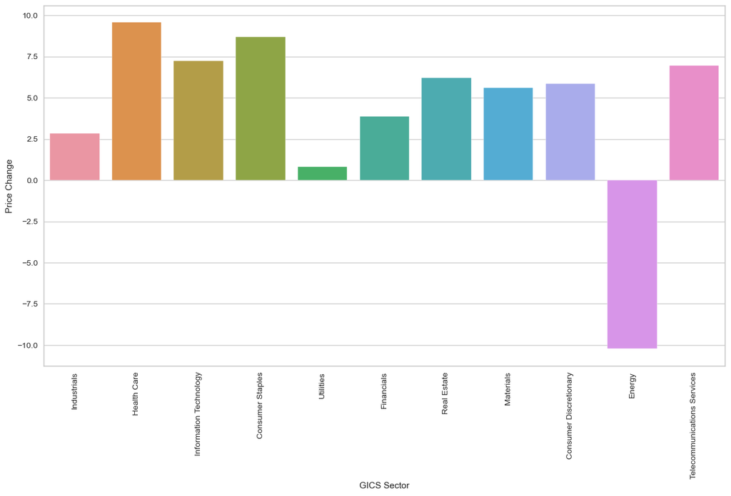

```python
plt.figure(figsize=(15,8))
sns.barplot(data=df, x='GICS Sector', y='Price Change', ci=False)
plt.xticks(rotation=90)
plt.show()
```

Podemos observar que el sector que mas aumento ha tenido es el sector de "Health Care".

### El índice de efectivo proporciona una medida de la capacidad de una empresa para cubrir sus obligaciones a corto plazo utilizando solo efectivo y equivalentes de efectivo. ¿Cómo varía la razón de efectivo promedio entre los sectores económicos?

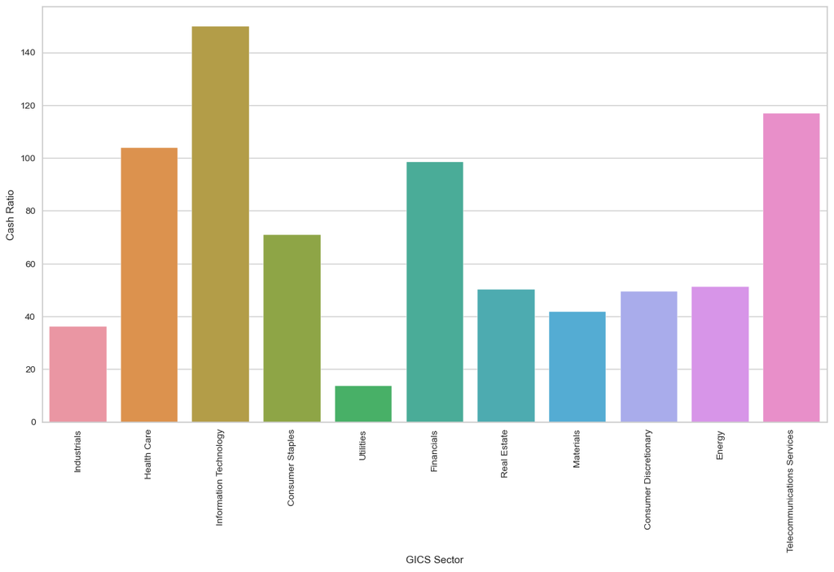

```python
plt.figure(figsize=(15,8))
sns.barplot(data=df, x='GICS Sector', y='Cash Ratio', ci=False)
plt.xticks(rotation=90)
plt.show()
```

Sectores con Mayor Liquidez: Los sectores con barras más altas tienen un Cash Ratio promedio más alto, lo que sugiere que las empresas en estos sectores pueden tener una mayor capacidad para cubrir sus pasivos a corto plazo con efectivo y equivalentes de efectivo.

Sectores con Menor Liquidez: Los sectores con barras más bajas tienen un Cash Ratio promedio más bajo, lo que puede indicar una menor liquidez en comparación con otros sectores. Esto podría interpretarse como una mayor propensión a financiar sus operaciones a través de deudas o que tienen inversiones significativas en activos no líquidos.

Variabilidad entre Sectores: La variabilidad en la altura de las barras entre diferentes sectores puede reflejar las diferentes prácticas de gestión de efectivo y estructuras de capital en esas industrias. Algunos sectores pueden naturalmente mantener más efectivo debido a la volatilidad de sus ingresos o las necesidades de inversión, mientras que otros pueden operar eficientemente con menos efectivo.

### Las relaciones P/E pueden ayudar a determinar el valor relativo de las acciones de una empresa, ya que representan la cantidad de dinero que un inversionista está dispuesto a invertir en una sola acción de una empresa por cada dólar de sus ganancias. ¿Cómo varía la relación P/E, en promedio, entre sectores económicos?

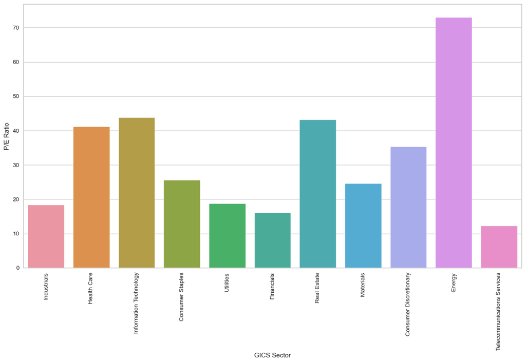

```python
plt.figure(figsize=(15,8))
sns.barplot(data=df, x='GICS Sector', y='P/E Ratio', ci=False)
plt.xticks(rotation=90)
plt.show()
```

Materiales y Bienes de Consumo No Cíclicos: Estos sectores tienen relaciones P/E moderadas, lo que podría indicar una valoración más balanceada entre el precio de las acciones y las ganancias actuales.

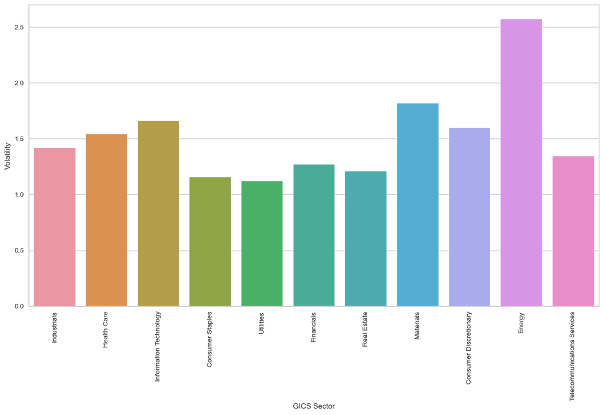

```python
plt.figure(figsize=(15,8))
sns.barplot(data=df, x='GICS Sector', y='Volatility', ci=False)
plt.xticks(rotation=90)
plt.show()
```

Energía: Este sector muestra la mayor volatilidad, lo cual es consistente con la naturaleza del mercado de la energía, que puede ser altamente sensible a eventos políticos, ambientales y cambios en la economía global.

Salud, Cuidado de la Salud y Tecnología de la Información: Estos sectores tienen niveles de volatilidad moderados. Esto puede deberse a la innovación constante y a la demanda estable de productos y servicios de salud y tecnología, lo que puede llevar a movimientos de precios más predecibles.

## Preprocesamiento de datos

- Comprobación de valores duplicados
- Tratamiento de valores perdidos
- Comprobación de valores atípicos
- Ingeniería de características (si es necesario)
- Cualquier otro paso de preprocesamiento (si es necesario)

### Comprobacion de valores atipicos

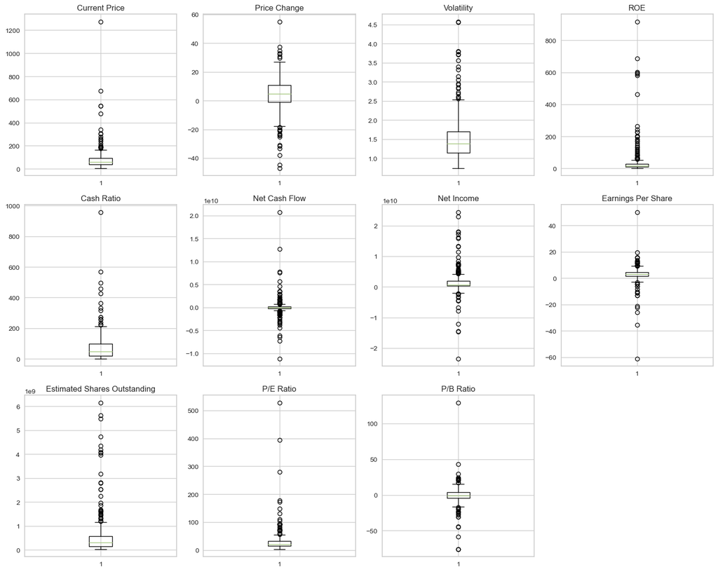

```python
plt.figure(figsize=(15, 12))

numeric_columns = df.select_dtypes(include=np.number).columns.tolist()

for i, variable in enumerate(numeric_columns):
    plt.subplot(3, 4, i + 1)
    plt.boxplot(df[variable], whis=1.5)
    plt.tight_layout()
    plt.title(variable)

plt.show()
```

Precio Actual (Current Price): Hay una amplia gama de precios de acciones, con una concentración de valores más bajos y algunos valores extremadamente altos que sobresalen como atípicos. Esto sugiere una gran variabilidad en el valor de mercado de las empresas incluidas en el análisis.

Cambio de Precio (Price Change): Muestra una distribución relativamente simétrica alrededor de la mediana con algunos valores atípicos, tanto positivos como negativos. Esto indica fluctuaciones de precios significativas para ciertas acciones dentro del período analizado.

Volatilidad: Se observan valores atípicos por encima del rango intercuartílico superior, lo que indica que algunas acciones son mucho más volátiles que otras. Esto es importante para el perfil de riesgo de la inversión.

ROE: La mayoría de las empresas tienen un ROE bajo, pero hay algunas con valores muy altos, lo que podría indicar una eficiencia excepcional en la generación de ganancias desde el punto de vista del accionista o un apalancamiento financiero significativo.

Cash Ratio: La mayoría de las empresas tienen un ratio de efectivo bajo, con algunos valores atípicos altos. Un alto cash ratio podría sugerir que la empresa tiene una buena capacidad para pagar sus deudas a corto plazo.

Net Cash Flow: Los flujos de caja netos tienen una distribución centrada, con algunos valores atípicos significativos en ambos extremos, indicando algunas empresas con flujos de caja excepcionalmente altos o bajos.

Net Income: Similar a Net Cash Flow, la mayoría de las empresas tienen ingresos netos moderados, con algunas excepciones notables.

Earnings Per Share (EPS): Hay una variabilidad significativa en las ganancias por acción, con valores atípicos en ambos extremos, lo que indica algunas empresas con desempeño excepcionalmente bueno o malo.

Estimated Shares Outstanding: La cantidad de acciones en circulación varía ampliamente, con varios valores atípicos que sugieren que algunas empresas tienen muchas más acciones disponibles para el comercio que otras.

P/E Ratio: Hay una gran cantidad de valores atípicos, lo que indica que para algunas empresas los inversores están dispuestos a pagar mucho más por las ganancias.

P/B Ratio: Al igual que con el P/E, hay una amplia gama de ratios con valores atípicos que pueden sugerir que algunas empresas tienen activos significativamente subvalorados o sobrevalorados.